# Prosper Loan Data

## Univariate Exploration

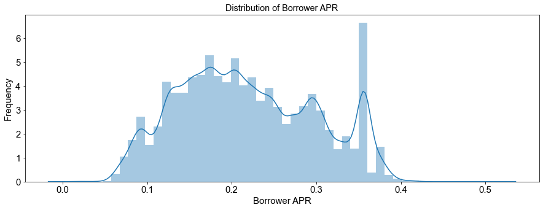

```python
#This distripution plot to show the distribution of BorrowerAPR
sns.distplot(ProsperLoans_Copy['BorrowerAPR']).set_title('Distribution of Borrower APR' , fontsize='x-large')
#Use this code to define the boundaries of the chart
plt.gcf().set_size_inches(15 , 5)
#Use this code to define the white color as the background of the chart
sns.set_style('whitegrid')
plt.xlabel('Borrower APR', fontsize=15)
plt.ylabel('Frequency', fontsize=15)
```

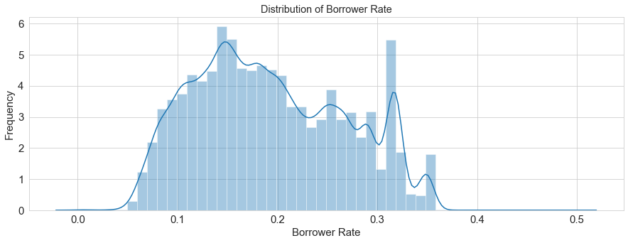

```python
#This distripution plot to show the distribution of Borrower Rate
sns.distplot(ProsperLoans_Copy['BorrowerRate']).set_title('Distribution of Borrower Rate' , fontsize='x-large')
#Use this code to define the boundaries of the chart
plt.gcf().set_size_inches(15 , 5)
#Use this code to define the white color as the background of the chart
sns.set_style('whitegrid')
plt.xlabel('Borrower Rate', fontsize=15)
plt.ylabel('Frequency', fontsize=15)
```

```python
#Print the values in 'LoanStatus' column
Loan_Status =ProsperLoans_Copy['LoanStatus'].value_counts()
Loan_Status
```

```
Current                   56576
Completed                 38074
Chargedoff                11992
Defaulted                  5018
Past Due (1-15 days)        806
Past Due (31-60 days)       363
Past Due (61-90 days)       313
Past Due (91-120 days)      304
Past Due (16-30 days)       265
FinalPaymentInProgress      205
Past Due (>120 days)         16
Cancelled                     5
Name: LoanStatus, dtype: int64
```

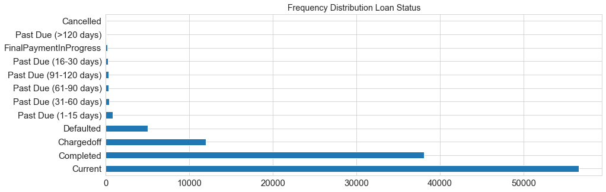

```python
#Draw bar chart for LoanStatus frequency distribution
Loan_Status.plot.barh().set_title('Frequency Distribution Loan Status' , fontsize='x-large')
#Use this code to define the boundaries of the chart
plt.gcf().set_size_inches(15 , 5)
```

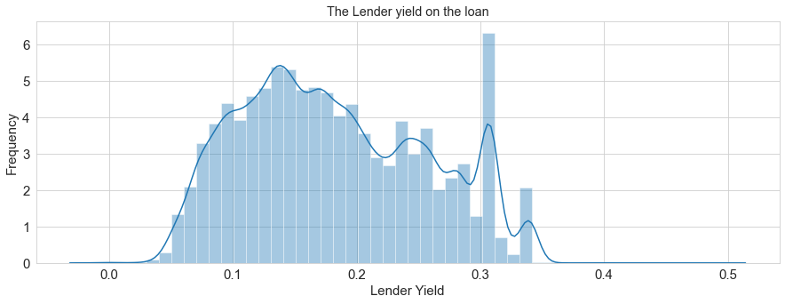

```python
#This distripution plot to show the distribution of the Lender yield on the loan
sns.distplot(ProsperLoans_Copy['LenderYield']).set_title('The Lender yield on the loan' , fontsize='x-large')
#Use this code to define the boundaries of the chart
plt.gcf().set_size_inches(15 , 5)
#Use this code to define the white color as the background of the chart
sns.set_style('whitegrid')
plt.xlabel('Lender Yield', fontsize=15)
plt.ylabel('Frequency', fontsize=15)
```

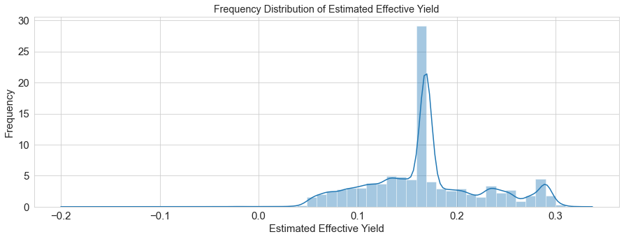

```python
#This distripution plot to show the distribution of Estimated Effective Yield
sns.distplot(ProsperLoans_Copy['EstimatedEffectiveYield']).set_title('Frequency Distribution of Estimated Effective Yield' , fontsize='x-large')
#Use this code to define the boundaries of the chart
plt.gcf().set_size_inches(15 , 5)
#Use this code to define the white color as the background of the chart
sns.set_style('whitegrid')
plt.xlabel('Estimated Effective Yield', fontsize=15)
plt.ylabel('Frequency', fontsize=15)
```

'EstimatedEffectiveYield' has a normal distribution with some values that have a high frequency.

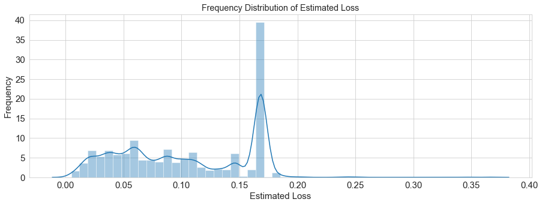

```python
#This distripution plot to show the distribution of Estimated Loss
sns.distplot(ProsperLoans_Copy['EstimatedLoss']).set_title('Frequency Distribution of Estimated Loss' , fontsize='x-large')
#Use this code to define the boundaries of the chart
plt.gcf().set_size_inches(15 , 5)
#Use this code to define the white color as the background of the chart
sns.set_style('whitegrid')
plt.xlabel('Estimated Loss', fontsize=15)
plt.ylabel('Frequency', fontsize=15)
```

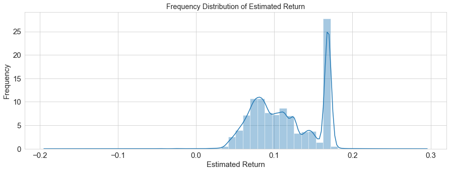

```python
#This distripution plot to show the distribution of Estimated Return
sns.distplot(ProsperLoans_Copy['EstimatedReturn']).set_title('Frequency Distribution of Estimated Return' , fontsize='x-large')
#Use this code to define the boundaries of the chart
plt.gcf().set_size_inches(15 , 5)
#Use this code to define the white color as the background of the chart
sns.set_style('whitegrid')
plt.xlabel('Estimated Return', fontsize=15)
plt.ylabel('Frequency', fontsize=15)
```

```python
#Print the values in 'IncomeRange' column
Income_Range = ProsperLoans_Copy['IncomeRange'].value_counts()
Income_Range
```

```
$25,000-49,999    32192
$50,000-74,999    31050
$100,000+         17337
$75,000-99,999    16916
Not displayed      7741
$1-24,999          7274
Not employed        806
$0                  621
Name: IncomeRange, dtype: int64
```

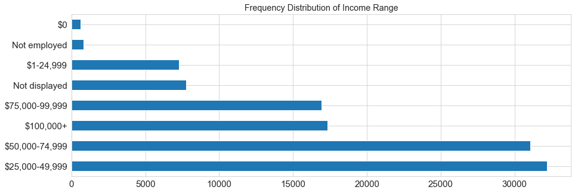

```python
#Draw bar chart for frequency distribution of Income Range
Income_Range.plot.barh().set_title('Frequency Distribution of Income Range' , fontsize='x-large')
#Use this code to define the boundaries of the chart
plt.gcf().set_size_inches(15 , 5)
```

The plot above shows that the Income Range between 25,000 - 49,000.

```python
#Print the values in 'Recommendations' column
Recommendations = ProsperLoans_Copy['Recommendations'].value_counts()
Recommendations
```

```
0     109678
1       3516
2        568
3        108
4         26
5         14
9          6
7          5
6          4
8          3
16         2
18         2
24         1
14         1
19         1
21         1
39         1
Name: Recommendations, dtype: int64
```

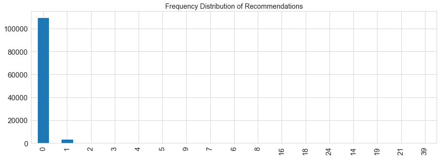

```python
#Draw bar chart for LoanStatus
Recommendations.plot.bar().set_title('Frequency Distribution of Recommendations' , fontsize='x-large')
#Use this code to define the boundaries of the chart
plt.gcf().set_size_inches(15 , 5)
```

The most common frequent value in 'Recommendations' collumn is Zero

```python
#Prrint the values of 'Term' column
Term = ProsperLoans_Copy['Term'].value_counts()
Term
```

```
36    87778
60    24545
12     1614
Name: Term, dtype: int64
```

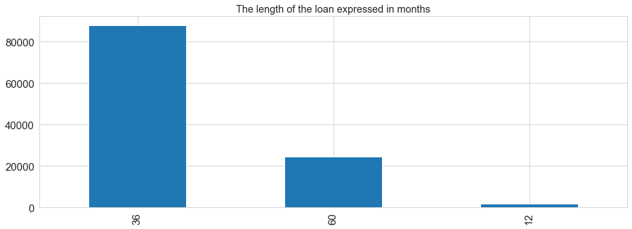

```python
#Draw bar chart for 'Trem' column
Term.plot.bar().set_title('The length of the loan expressed in months' , fontsize='x-large')
#Use this code to define the boundaries of the chart
plt.gcf().set_size_inches(15 , 5)
```

36 is the most frequent term in the 'Term' variable. Also, it followed by 60 then 12.

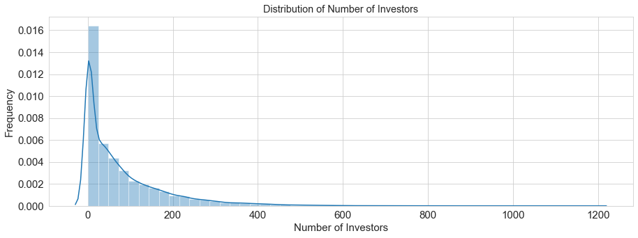

```python
#This distripution plot to show the distribution of Number of Investors
sns.distplot(ProsperLoans_Copy['Investors']).set_title('Distribution of Number of Investors' , fontsize='x-large')
#Use this code to define the boundaries of the chart
plt.gcf().set_size_inches(15 , 5)
#Use this code to define the white color as the background of the chart
sns.set_style('whitegrid')
plt.xlabel('Number of Investors', fontsize=15)
plt.ylabel('Frequency', fontsize=15)
```

The chart above is skewed. so, I will use Log transformation.

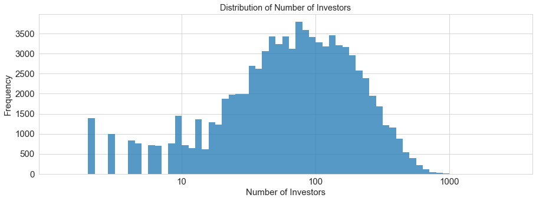

```python
#This distripution plot to show the distribution of Number of Investors after log transformation
log_binsize = 0.05
bins = 10 ** np.arange(0.1, 3.5, log_binsize)
sns.histplot(ProsperLoans_Copy['Investors'], bins = bins).set_title('Distribution of Number of Investors' , fontsize='x-large')
#Use this code to define the boundaries of the chart
plt.gcf().set_size_inches(15 , 5)
#Use this code to define the white color as the background of the chart
sns.set_style('whitegrid')
plt.xlabel('Number of Investors', fontsize=15)
plt.ylabel('Frequency', fontsize=15)
plt.xscale('log')
plt.xticks([1e1, 1e2, 1e3], ['10', '100', '1000'])
plt.show()
```

The number of investors almost have normal distribution around 60 to 80

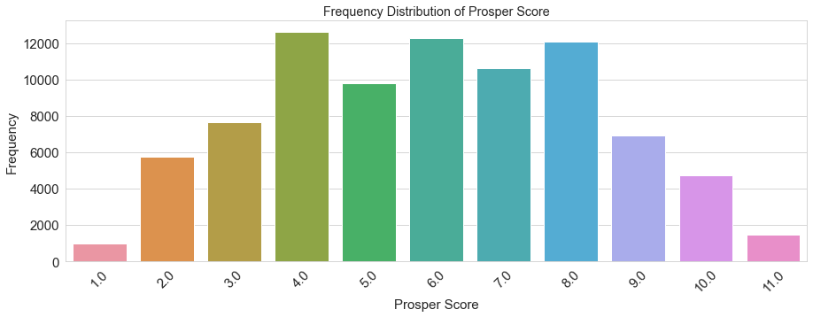

```python
#This distripution plot to show the Distribution of Prosper Score
sns.countplot(ProsperLoans['ProsperScore']).set_title('Frequency Distribution of Prosper Score' , fontsize='x-large' )
#Use this code to define the boundaries of the chart
plt.gcf().set_size_inches(15 , 5)
plt.xticks(rotation=45)
#Use this code to define the white color as the background of the chart
sns.set_style('whitegrid')
plt.xlabel('Prosper Score', fontsize=15)
plt.ylabel('Frequency', fontsize=15)
```

- Through the bar chart, I conclude that most people has score ranging from 3.0 to 9.0.
- 4.0, 6.0 and 8.0 scors are the highest frequencies.

```
'50.4%'
```

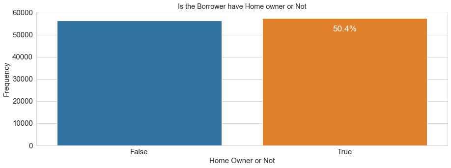

```python
#Just compare the string to whatever I expect to accept as representing True and
#Checks against a whole bunch of values
def str_to_bool(v):
    return str(v).lower() in ("yes", "true", "True", "1")
#This distripution plot to show if the brrower have home or not
sns.countplot(data =ProsperLoans_Copy, x = 'IsBorrowerHomeowner').set_title('Is the Borrower have Home owner or Not' , fontsize='x-large' )
#Point of start
Points_of_start =ProsperLoans_Copy.shape[0]
HomeOwner =  ProsperLoans_Copy['IsBorrowerHomeowner'].value_counts()
# Rturn locations and Lables
# Locations is an array of tick location and Labels is an array of tick lables
Locations, Labels = plt.xticks()
#loop through the locations and labels
for Location, Label in zip(Locations, Labels):

    #Return ValueCount of HomeOwner
    ValueCount = HomeOwner[str_to_bool(Label.get_text())]
    #Return Percentage depend on ValueCount
    Percentage = '{:0.1f}%'.format(100*ValueCount/Points_of_start)
    #print the annotation just below the top of the bar
plt.text(Location,  ValueCount-6000, Percentage, ha = 'center', c = 'w', fontsize = 'xx-large')
#Use this code to define the white color as the background of the chart
plt.gcf().set_size_inches(15 , 5)
plt.xlabel('Home Owner or Not', fontsize=15)
plt.ylabel('Frequency', fontsize=15)
#Customize the size of figure
plt.figure(figsize=[6,5])
Percentage
```

- Home owner borrower have highest value than the borrower that they dont have home.
- 50.4% is a Home Owner.
- 49.6% do not have homes.

### Discuss the distribution(s) of your variable(s) of interest. Were there any unusual points? Did you need to perform any transformations?

- The distibution is normal with high frequency of high-valued points towards the tail of the distibution.
- All variables have frequent values toward the tails of the distribution.

### Of the features you investigated, were there any unusual distributions? Did you perform any operations on the data to tidy, adjust, or change the form of the data? If so, why did you do this?

- The 'Investors' variable is significantly skewed. So I use the Log transformation.

## Bivariate Exploration

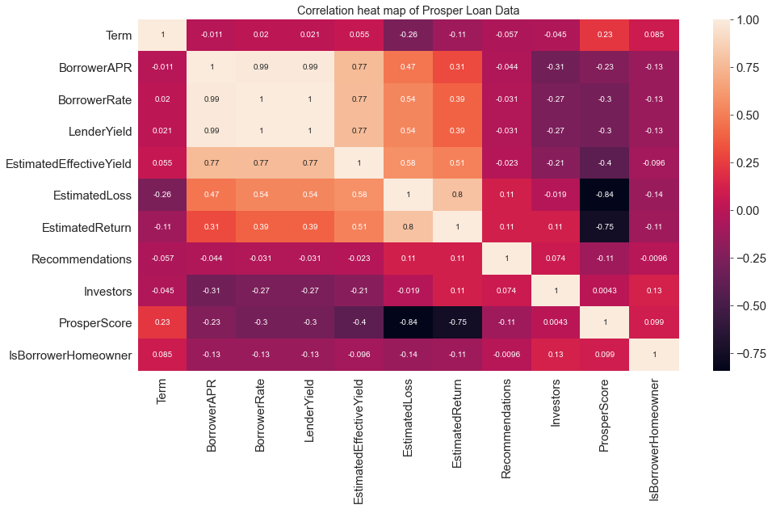

```python
#Use Correlation to Check the relationship between the numerical variables
corr = ProsperLoans_Copy.corr()
sns.heatmap(corr, annot=True).set_title('Correlation heat map of Prosper Loan Data', fontsize='x-large')
#Use this code to define the boundaries of the chart
plt.gcf().set_size_inches(15 , 8)
plt.show()
```

##### Sometimes a negative correlation is logical and meaningful, I noticed from the previous chart some negative values that are meaningful. Like:

- 'BorrowerAPR and ProsperScore' have a negative correlation,The lower ProsperScor, leads to an increase in risks, and therefore interest rates will increase.
- 'LenderYield and ProsperScore' have a negative correlation, The higher ProsperScor, the interest rate will decrease, and therefore the return on the lender will decrease.

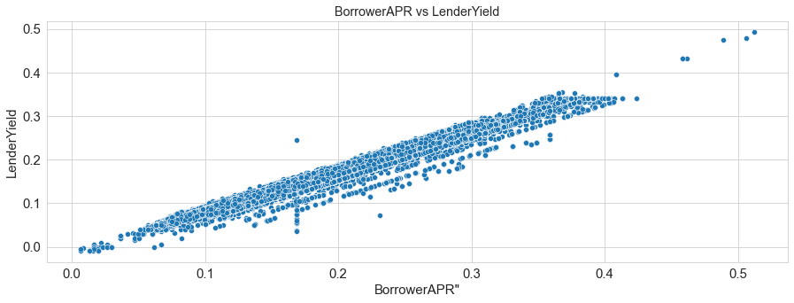

```python
#This scatter plot to show the relation between BorrowerAPR and LenderYield
sns.scatterplot(data=ProsperLoans_Copy, x="BorrowerAPR", y="LenderYield").set_title('BorrowerAPR vs LenderYield' , fontsize='x-large')
#Use this code to define the boundaries of the chart
plt.gcf().set_size_inches(15 , 5)
#Use this code to define the white color as the background of the chart
sns.set_style('whitegrid')
plt.xlabel('BorrowerAPR"', fontsize=15)
plt.ylabel('LenderYield', fontsize=15)
```

Correlation between BorrowerAPR and LenderYield = 0.99 it is a very strong relationship which means The higher the Annual Percentage Rate the higher the lenderYield 'the interest rate on the loan'.

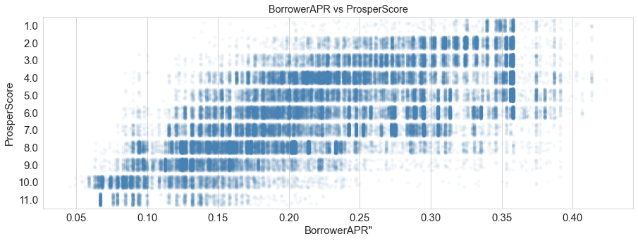

```python
#This scatter plot to show the relation between BorrowerAPR and ProsperScore
sns.stripplot(data=ProsperLoans, x="BorrowerAPR", y="ProsperScore", orient='h', jitter=0.35, color='steelblue' , alpha=0.05).set_title('BorrowerAPR vs ProsperScore' , fontsize='x-large')
#Use this code to define the boundaries of the chart
plt.gcf().set_size_inches(15 , 5)
#Use this code to define the white color as the background of the chart
sns.set_style('whitegrid')
plt.xlabel('BorrowerAPR"', fontsize=15)
plt.ylabel('ProsperScore', fontsize=15);
```

'BorrowerAPR and ProsperScore' have a negative correlation,The lower ProsperScor, This leads to an increase in risks, and therefore interest rates will increase.

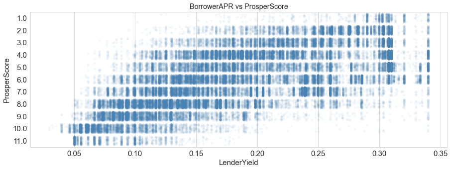

```python
#This scatter plot to show the relation between BorrowerAPR and ProsperScore
sns.stripplot(data=ProsperLoans , x="LenderYield", y="ProsperScore", orient='h', jitter=0.35, color='steelblue' , alpha=0.05).set_title('BorrowerAPR vs ProsperScore' , fontsize='x-large')
#Use this code to define the boundaries of the chart
plt.gcf().set_size_inches(15 , 5)
#Use this code to define the white color as the background of the chart
sns.set_style('whitegrid')
plt.xlabel('LenderYield', fontsize=15)
plt.ylabel('ProsperScore', fontsize=15)
```

'LenderYield and ProsperScore' have a negative correlation, The higher ProsperScor, the interest rate will decrease, and therefore the return on the lender will decrease.

### Here I will plotting som charts to check the relation between the categorical variables and the features of interest: BorrowerRate and BorrowerAPR.

```python
#This function to plot all box plots
def AllBoxPlot (df,xVar,yVar):

    sns.boxplot(data=df.sort_values(by=xVar), x=yVar, y=xVar, orient='h').set_title(f'{yVar} vs {xVar}' , fontsize='x-large')
#Use this code to define the boundaries of the chart
    plt.gcf().set_size_inches(14 , 8)
#Use this code to put the title and its proparities
    plt.title(f'Distribution of {yVar} by {xVar}'.title(), fontsize = 14 , weight = "bold")
#Use this code to put x and labeles and its proparities
    plt.xlabel(yVar.title(), fontsize= 10, weight = "bold")
    plt.ylabel(xVar.title(), fontsize= 10, weight = "bold");
```

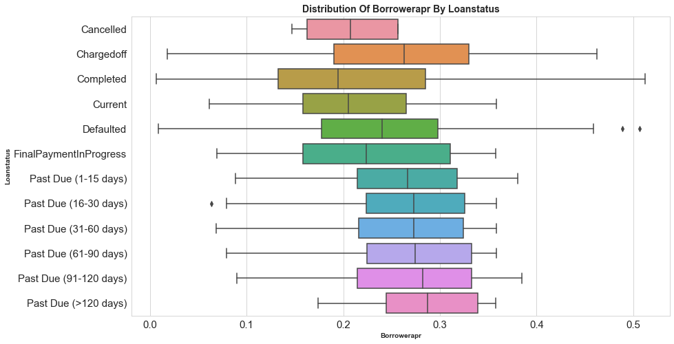

```python
#This box plot to show the distribution of LoanStatus and BorrowerAPR
AllBoxPlot(ProsperLoans_Copy,'LoanStatus','BorrowerAPR')
```

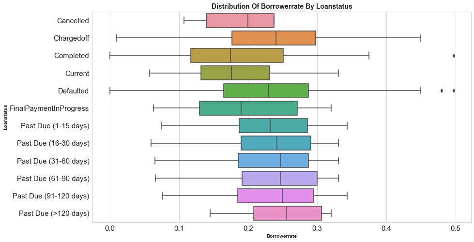

```python
#This box plot to show the distribution of LoanStatus and BorrowerRate
AllBoxPlot(ProsperLoans_Copy,'LoanStatus','BorrowerRate')
```

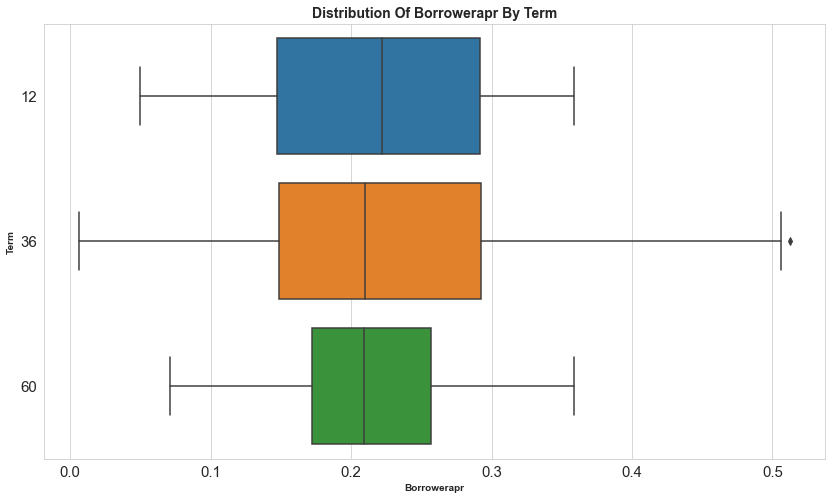

```python
#This box plot to show the relation between BorrowerAPR and Term
AllBoxPlot(ProsperLoans_Copy,'Term','BorrowerAPR')
```

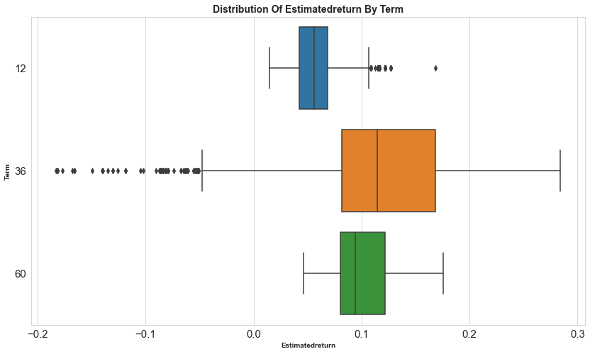

```python
#This box plot to show the relation between Term and Estimated Return
AllBoxPlot(ProsperLoans_Copy,'Term','EstimatedReturn')
```

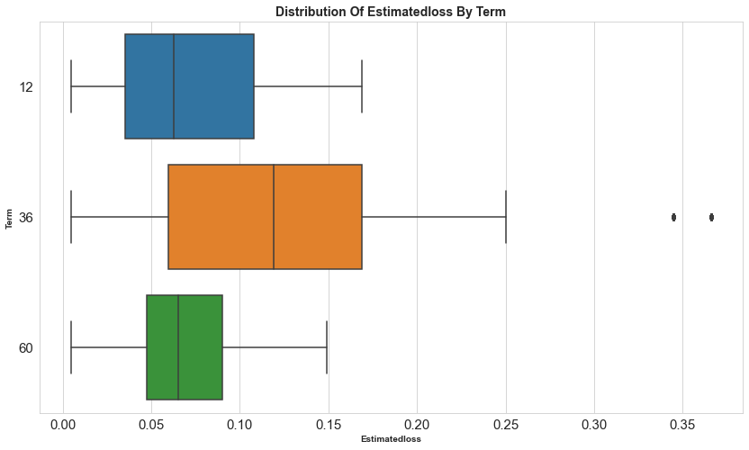

```python
#This box plot to show the relation between EstimatedLoss and Term
AllBoxPlot(ProsperLoans_Copy,'Term','EstimatedLoss')
```

- The 'EstimatedLoss' on a loan varies over time for a number of reasons. Most loans are repaid over time and therefore have a declining outstanding amount to be repaid. Additionally, loans are typically backed up by pledged collateral whose value changes differently over time vs. the outstanding loan value.

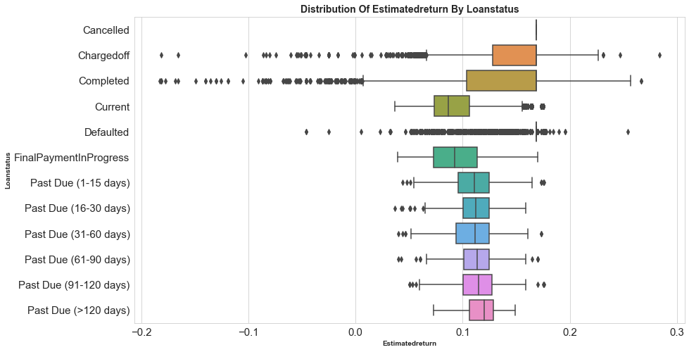

```python
#This box plot to show the relation between LoanStatus and EstimatedReturn
AllBoxPlot(ProsperLoans_Copy,'LoanStatus','EstimatedReturn')
```

- 'Current' and 'FinalPaymentInProgress' have the lowest Estimated Return.
- 'Chargedoff' and 'defaulted' have the highest median of Estimated Return.

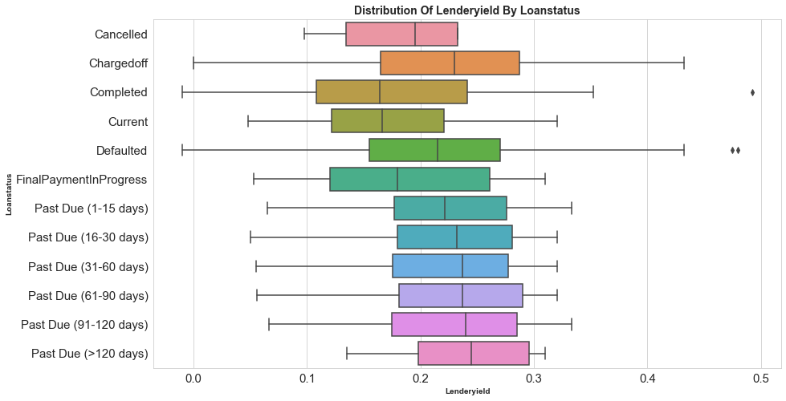

```python
#This box plot to show the relation between LoanStatus and LenderYield
AllBoxPlot(ProsperLoans_Copy,'LoanStatus','LenderYield')
```

- positive correlation between LenderYield and LoanStatus. So we can see that the 'completed' Status is much more common with smaller Lender Yields.

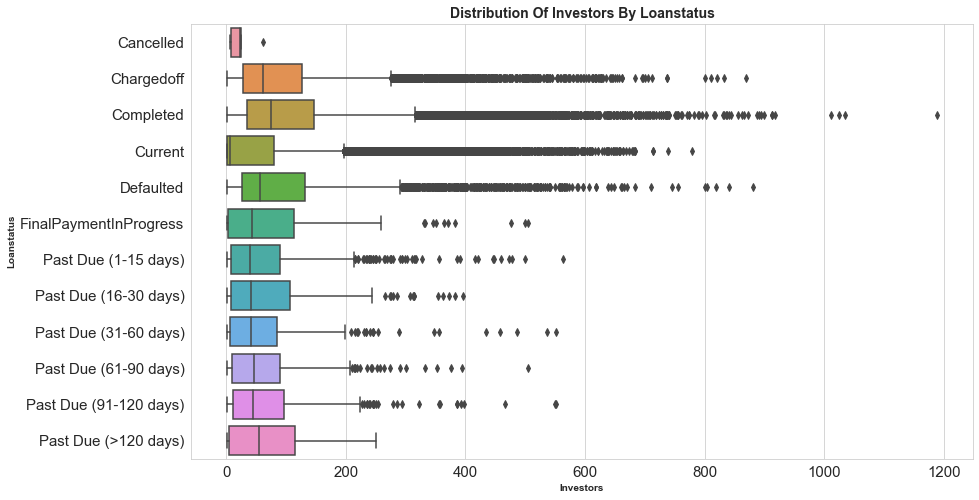

```python
#This box plot to show the relation between LoanStatus and Investors
AllBoxPlot(ProsperLoans_Copy,'LoanStatus','Investors')
```

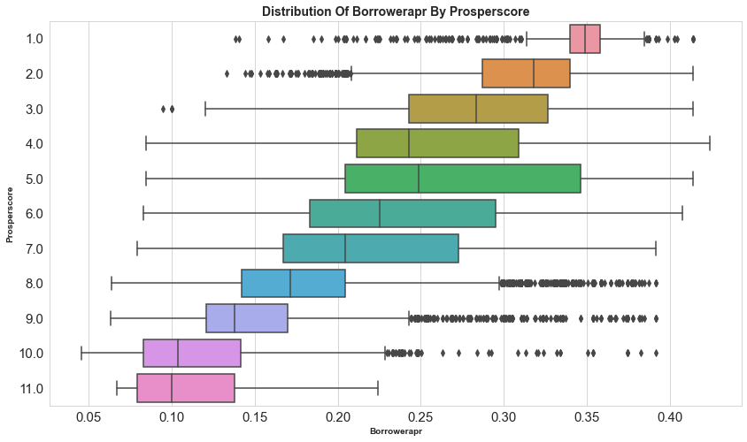

```python
#This box plot to show the relation between ProsperScore and BorrowerAPR
AllBoxPlot(ProsperLoans,'ProsperScore','BorrowerAPR')
```

- The box plot shows that there is an indications that 'Prosperscore' is a good factor to determine the 'BorrowersAPR'. the lower ProsperScor, This leads to an increase in risks, and therefore interest rates will increase.

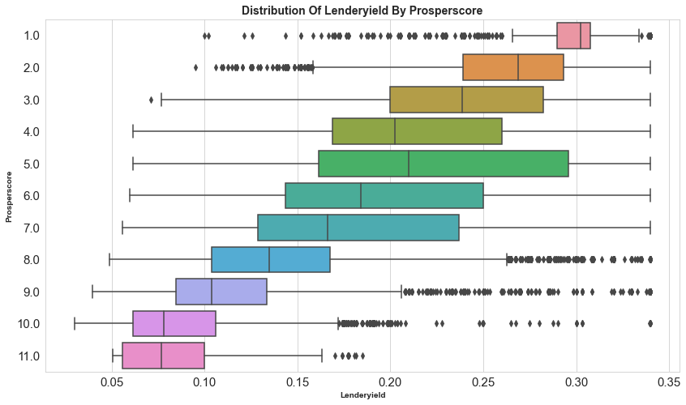

```python
#This box plot to show the relation between ProsperScore and BorrowerAPR
AllBoxPlot(ProsperLoans,'ProsperScore','LenderYield')
```

- 'LenderYield and ProsperScore' have a negative correlation, The higher ProsperScor, the interest rate will decrease, and therefore the return on the lender will decrease.

```python
#Extract the year only from the ListingCreationDate
ProsperLoans_Copy['Yearly_Rate'] = ProsperLoans_Copy['ListingCreationDate'].astype(str).str[:4]
```

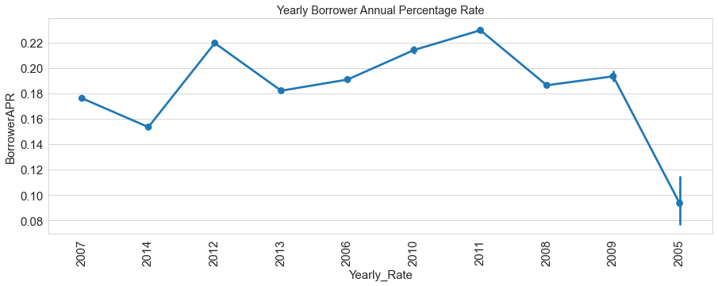

```python
#This box plot to show the distribution of Yearly Borrower Annual Percentage Rate
sns.pointplot(data=ProsperLoans_Copy, x="Yearly_Rate" , y="BorrowerRate").set_title('Yearly Borrower Annual Percentage Rate' , fontsize='x-large')
#Use this code to define the boundaries of the chart
plt.xticks(rotation = 90);
plt.gcf().set_size_inches(15 , 5)
#Use this code to define the white color as the background of the chart
sns.set_style('whitegrid')
plt.xlabel('Yearly_Rate', fontsize=15)
plt.ylabel('BorrowerAPR', fontsize=15)
```

The 'BorrwerRate' was high in 2011 , 2012 and it became down in 2014.